# Traffic Crashses in Chicago

## Data Description:

Crash data shows information about each traffic crash on city streets within the City of Chicago limits and under the jurisdiction of Chicago Police Department (CPD). Data are shown as is from the electronic crash reporting system (E-Crash) at CPD, excluding any personally identifiable information. Records are added to the data portal when a crash report is finalized or when amendments are made to an existing report in E-Crash. Data from E-Crash are available for some police districts in 2015, but citywide data are not available until September 2017.

About half of all crash reports, mostly minor crashes, are self-reported at the police district by the driver(s) involved and the other half are recorded at the scene by the police officer responding to the crash. Many of the crash parameters, including street condition data, weather condition, and posted speed limits, are recorded by the reporting officer based on best available information at the time, but many of these may disagree with posted information or other assessments on road conditions. If any new or updated information on a crash is received, the reporting officer may amend the crash report at a later time.

### Columns in this Dataset

| Column Name | Description |
| --- | --- |
| RD_NO | Chicago Police Department report number. This number can be used to link to the same crash in the Vehicles and People datasets. This number also serves as a unique ID in this dataset. |
| CRASH_DATE_EST_I | Crash date estimated by desk officer or reporting party (only used in cases where crash is reported at police station days after the crash) |
| CRASH_DATE | Date and time of crash as entered by the reporting officer |
| POSTED_SPEED_LIMIT | Posted speed limit, as determined by reporting officer |
| TRAFFIC_CONTROL_DEVICE | Traffic control device present at crash location, as determined by reporting officer |
| DEVICE_CONDITION | Condition of traffic control device, as determined by reporting officer |
| WEATHER_CONDITION | Weather condition at time of crash, as determined by reporting officer |
| LIGHTING_CONDITION | Light condition at time of crash, as determined by reporting officer |
| FIRST_CRASH_TYPE | Type of first collision in crash |
| TRAFFICWAY_TYPE | Trafficway type, as determined by reporting officer |
| LANE_CNT | Total number of through lanes in either direction, excluding turn lanes, as determined by reporting officer (0 = intersection) |
| ALIGNMENT | Street alignment at crash location, as determined by reporting officer |
| ROADWAY_SURFACE_COND | Road surface condition, as determined by reporting officer |
| ROAD_DEFECT | Road defects, as determined by reporting officer |
| REPORT_TYPE | Administrative report type (at scene, at desk, amended) |
| CRASH_TYPE | A general severity classification for the crash. Can be either Injury and/or Tow Due to Crash or No Injury / Drive Away |
| INTERSECTION_RELATED_I | A field observation by the police officer whether an intersection played a role in the crash. Does not represent whether or not the crash occurred within the intersection. |
| NOT_RIGHT_OF_WAY_I | Whether the crash begun or first contact was made outside of the public right-of-way. |
| HIT_AND_RUN_I | Crash did/did not involve a driver who caused the crash and fled the scene without exchanging information and/or rendering aid |
| DAMAGE | A field observation of estimated damage. |
| DATE_POLICE_NOTIFIED | Calendar date on which police were notified of the crash |
| PRIM_CONTRIBUTORY_CAUSE | The factor which was most significant in causing the crash, as determined by officer judgment |
| SEC_CONTRIBUTORY_CAUSE | The factor which was second most significant in causing the crash, as determined by officer judgment |
| STREET_NO | Street address number of crash location, as determined by reporting officer |
| STREET_DIRECTION | Street address direction (N,E,S,W) of crash location, as determined by reporting officer |
| STREET_NAME | Street address name of crash location, as determined by reporting officer |
| BEAT_OF_OCCURRENCE | Chicago Police Department Beat ID. Boundaries available at https://data.cityofchicago.org/d/aerh-rz74 |
| PHOTOS_TAKEN_I | Whether the Chicago Police Department took photos at the location of the crash |
| STATEMENTS_TAKEN_I | Whether statements were taken from unit(s) involved in crash |
| DOORING_I | Whether crash involved a motor vehicle occupant opening a door into the travel path of a bicyclist, causing a crash |
| WORK_ZONE_I | Whether the crash occurred in an active work zone |
| WORK_ZONE_TYPE | The type of work zone, if any |
| WORKERS_PRESENT_I | Whether construction workers were present in an active work zone at crash location |
| NUM_UNITS | Number of units involved in the crash. A unit can be a motor vehicle, a pedestrian, a bicyclist, or another non-passenger roadway user. Each unit represents a mode of traffic with an independent traje… |
| MOST_SEVERE_INJURY | Most severe injury sustained by any person involved in the crash |
| INJURIES_TOTAL | Total persons sustaining fatal, incapacitating, non-incapacitating, and possible injuries as determined by the reporting officer |
| INJURIES_FATAL | Total persons sustaining fatal injuries in the crash |
| INJURIES_INCAPACITATING | Total persons sustaining incapacitating/serious injuries in the crash as determined by the reporting officer. Any injury other than fatal injury, which prevents the injured person from walking, drivin… |
| INJURIES_NON_INCAPACITATING | Total persons sustaining non-incapacitating injuries in the crash as determined by the reporting officer. Any injury, other than fatal or incapacitating injury, which is evident to observers at the sc… |
| INJURIES_REPORTED_NOT_EVIDENT | Total persons sustaining possible injuries in the crash as determined by the reporting officer. Includes momentary unconsciousness, claims of injuries not evident, limping, complaint of pain, nausea, … |
| INJURIES_NO_INDICATION | Total persons sustaining no injuries in the crash as determined by the reporting officer |
| INJURIES_UNKNOWN | Total persons for whom injuries sustained, if any, are unknown |
| CRASH_HOUR | The hour of the day component of CRASH_DATE. |
| CRASH_DAY_OF_WEEK | The day of the week component of CRASH_DATE. Sunday=1 |
| CRASH_MONTH | The month component of CRASH_DATE. |
| LATITUDE | The latitude of the crash location, as determined by reporting officer, as derived from the reported address of crash |
| LONGITUDE | The longitude of the crash location, as determined by reporting officer, as derived from the reported address of crash |
| LOCATION | The crash location, as determined by reporting officer, as derived from the reported address of crash, in a column type that allows for mapping and other geographic analysis in the data portal softwar… |

**Source:** https://data.cityofchicago.org/Transportation/Traffic-Crashes-Crashes/85ca-t3if/data

### Importing required packages

```python
# --------Print all the outputs in a cell--------
from IPython.core.interactiveshell import InteractiveShell
InteractiveShell.ast_node_interactivity = "all"
```

```python
import pandas as pd
import numpy as np
from mpl_toolkits.mplot3d import Axes3D
from sklearn.preprocessing import StandardScaler
import matplotlib.pyplot as plt
import seaborn as sns
import sklearn as sk
import sklearn.tree as tree
from IPython.display import Image
import pydotplus
```

### Reading the data from file

```python
df = pd.read_csv('Traffic_Crashes.csv',index_col=0)
```

```python
df.head(5)
```

| RD_NO | CRASH_DATE_EST_I | CRASH_DATE | POSTED_SPEED_LIMIT | TRAFFIC_CONTROL_DEVICE | DEVICE_CONDITION | WEATHER_CONDITION | LIGHTING_CONDITION | FIRST_CRASH_TYPE | TRAFFICWAY_TYPE | LANE_CNT | ... | INJURIES_NON_INCAPACITATING | INJURIES_REPORTED_NOT_EVIDENT | INJURIES_NO_INDICATION | INJURIES_UNKNOWN | CRASH_HOUR | CRASH_DAY_OF_WEEK | CRASH_MONTH | LATITUDE | LONGITUDE | LOCATION |
| --- | --- | --- | --- | --- | --- | --- | --- | --- | --- | --- | --- | --- | --- | --- | --- | --- | --- | --- | --- | --- | --- |
| JC273063 | NaN | 05/22/2019 12:20:00 AM | 25 | STOP SIGN/FLASHER | FUNCTIONING PROPERLY | OTHER | DARKNESS, LIGHTED ROAD | ANGLE | FOUR WAY | NaN | ... | 0.0 | 0.0 | 3.0 | 0.0 | 0 | 4 | 5 | 41.786556 | -87.691220 | POINT (-87.691220232664 41.786555633314) |
| JC273065 | NaN | 05/22/2019 12:00:00 AM | 30 | TRAFFIC SIGNAL | FUNCTIONING PROPERLY | RAIN | DARKNESS, LIGHTED ROAD | ANGLE | ONE-WAY | NaN | ... | 0.0 | 0.0 | 3.0 | 0.0 | 0 | 4 | 5 | 41.876785 | -87.633839 | POINT (-87.63383891021 41.876784831446) |
| JC273046 | NaN | 05/21/2019 11:40:00 PM | 30 | TRAFFIC SIGNAL | FUNCTIONING PROPERLY | RAIN | DARKNESS | TURNING | NOT DIVIDED | NaN | ... | 0.0 | 0.0 | 5.0 | 0.0 | 23 | 3 | 5 | 41.809082 | -87.631031 | POINT (-87.63103087365 41.809082436649) |
| JC273001 | NaN | 05/21/2019 09:30:00 PM | 15 | NO CONTROLS | NO CONTROLS | CLEAR | DARKNESS, LIGHTED ROAD | SIDESWIPE OPPOSITE DIRECTION | PARKING LOT | NaN | ... | 0.0 | 0.0 | 2.0 | 0.0 | 21 | 3 | 5 | 41.868890 | -87.639099 | POINT (-87.639098928088 41.868889711112) |
| JC272944 | NaN | 05/21/2019 09:24:00 PM | 30 | TRAFFIC SIGNAL | FUNCTIONING PROPERLY | CLEAR | DARKNESS | TURNING | DIVIDED - W/MEDIAN BARRIER | NaN | ... | 0.0 | 0.0 | 3.0 | 0.0 | 21 | 3 | 5 | 41.883234 | -87.636649 | POINT (-87.636649061859 41.883234347768) |

5 rows × 47 columns

### Different Columns in the data

```python
df.columns
```

```
Index(['CRASH_DATE_EST_I', 'CRASH_DATE', 'POSTED_SPEED_LIMIT',
       'TRAFFIC_CONTROL_DEVICE', 'DEVICE_CONDITION', 'WEATHER_CONDITION',
       'LIGHTING_CONDITION', 'FIRST_CRASH_TYPE', 'TRAFFICWAY_TYPE', 'LANE_CNT',
       'ALIGNMENT', 'ROADWAY_SURFACE_COND', 'ROAD_DEFECT', 'REPORT_TYPE',
       'CRASH_TYPE', 'INTERSECTION_RELATED_I', 'NOT_RIGHT_OF_WAY_I',
       'HIT_AND_RUN_I', 'DAMAGE', 'DATE_POLICE_NOTIFIED',
       'PRIM_CONTRIBUTORY_CAUSE', 'SEC_CONTRIBUTORY_CAUSE', 'STREET_NO',
       'STREET_DIRECTION', 'STREET_NAME', 'BEAT_OF_OCCURRENCE',
       'PHOTOS_TAKEN_I', 'STATEMENTS_TAKEN_I', 'DOORING_I', 'WORK_ZONE_I',
       'WORK_ZONE_TYPE', 'WORKERS_PRESENT_I', 'NUM_UNITS',
       'MOST_SEVERE_INJURY', 'INJURIES_TOTAL', 'INJURIES_FATAL',
       'INJURIES_INCAPACITATING', 'INJURIES_NON_INCAPACITATING',
       'INJURIES_REPORTED_NOT_EVIDENT', 'INJURIES_NO_INDICATION',
       'INJURIES_UNKNOWN', 'CRASH_HOUR', 'CRASH_DAY_OF_WEEK', 'CRASH_MONTH',
       'LATITUDE', 'LONGITUDE', 'LOCATION'],
      dtype='object')
```

## Data Cleaning

### Columns that have Nan

```python
df.isna().sum()
```

```
CRASH_DATE_EST_I                 277367
CRASH_DATE                            0
POSTED_SPEED_LIMIT                    0
TRAFFIC_CONTROL_DEVICE                0
DEVICE_CONDITION                      0
WEATHER_CONDITION                     0
LIGHTING_CONDITION                    0
FIRST_CRASH_TYPE                      0
TRAFFICWAY_TYPE                       0
LANE_CNT                         101295
ALIGNMENT                             0
ROADWAY_SURFACE_COND                  0
ROAD_DEFECT                           0
REPORT_TYPE                        6494
CRASH_TYPE                            0
INTERSECTION_RELATED_I           235169
NOT_RIGHT_OF_WAY_I               286148
HIT_AND_RUN_I                    216929
DAMAGE                                0
DATE_POLICE_NOTIFIED                  0
PRIM_CONTRIBUTORY_CAUSE               0
SEC_CONTRIBUTORY_CAUSE                0
STREET_NO                             0
STREET_DIRECTION                      2
STREET_NAME                           1
BEAT_OF_OCCURRENCE                    4
PHOTOS_TAKEN_I                   295964
STATEMENTS_TAKEN_I               293848
DOORING_I                        298835
WORK_ZONE_I                      297580
WORK_ZONE_TYPE                   298038
WORKERS_PRESENT_I                299326
NUM_UNITS                           714
MOST_SEVERE_INJURY                 1291
INJURIES_TOTAL                     1284
INJURIES_FATAL                     1284
INJURIES_INCAPACITATING            1284
INJURIES_NON_INCAPACITATING        1284
INJURIES_REPORTED_NOT_EVIDENT      1284
INJURIES_NO_INDICATION             1284
INJURIES_UNKNOWN                   1284
CRASH_HOUR                            0
CRASH_DAY_OF_WEEK                     0
CRASH_MONTH                           0
LATITUDE                           1284
LONGITUDE                          1284
LOCATION                           1284
dtype: int64
```

### Dropping Unnecessary Columns

```python
df.drop(['CRASH_DATE_EST_I', 'PHOTOS_TAKEN_I' , 'DOORING_I', 'WORK_ZONE_I','WORK_ZONE_TYPE','WORKERS_PRESENT_I'], axis = 1, inplace = True)
```

### Replacing Nan with 0 for some columns

```python
df['MOST_SEVERE_INJURY'].fillna(0 , inplace = True)
df['INJURIES_TOTAL'].fillna(0 , inplace = True)
df['INJURIES_FATAL'].fillna(0 , inplace = True)
df['INJURIES_INCAPACITATING'].fillna(0 , inplace = True)
df['INJURIES_NON_INCAPACITATING'].fillna(0 , inplace = True)
df['INJURIES_REPORTED_NOT_EVIDENT'].fillna(0 , inplace = True)
df['INJURIES_NO_INDICATION'].fillna(0 , inplace = True)
df['INJURIES_UNKNOWN'].fillna(0 , inplace = True)
```

### Dropping Rows that have NUM_UNITS as Nan

```python
df = df[np.isfinite(df['NUM_UNITS'])]
```

### Updated Columns

```python
df.columns
```

```
Index(['CRASH_DATE', 'POSTED_SPEED_LIMIT', 'TRAFFIC_CONTROL_DEVICE',
       'DEVICE_CONDITION', 'WEATHER_CONDITION', 'LIGHTING_CONDITION',
       'FIRST_CRASH_TYPE', 'TRAFFICWAY_TYPE', 'LANE_CNT', 'ALIGNMENT',
       'ROADWAY_SURFACE_COND', 'ROAD_DEFECT', 'REPORT_TYPE', 'CRASH_TYPE',
       'INTERSECTION_RELATED_I', 'NOT_RIGHT_OF_WAY_I', 'HIT_AND_RUN_I',
       'DAMAGE', 'DATE_POLICE_NOTIFIED', 'PRIM_CONTRIBUTORY_CAUSE',
       'SEC_CONTRIBUTORY_CAUSE', 'STREET_NO', 'STREET_DIRECTION',
       'STREET_NAME', 'BEAT_OF_OCCURRENCE', 'STATEMENTS_TAKEN_I', 'NUM_UNITS',
       'MOST_SEVERE_INJURY', 'INJURIES_TOTAL', 'INJURIES_FATAL',
       'INJURIES_INCAPACITATING', 'INJURIES_NON_INCAPACITATING',
       'INJURIES_REPORTED_NOT_EVIDENT', 'INJURIES_NO_INDICATION',
       'INJURIES_UNKNOWN', 'CRASH_HOUR', 'CRASH_DAY_OF_WEEK', 'CRASH_MONTH',
       'LATITUDE', 'LONGITUDE', 'LOCATION'],
      dtype='object')
```

### Checking Data Type for Crash Date

```python
df['CRASH_DATE'].head(5)
```

```
RD_NO
JC273063    05/22/2019 12:20:00 AM
JC273065    05/22/2019 12:00:00 AM
JC273046    05/21/2019 11:40:00 PM
JC273001    05/21/2019 09:30:00 PM
JC272944    05/21/2019 09:24:00 PM
Name: CRASH_DATE, dtype: object
```

### Changing Hit and Run value to Boolean and dropping the old column

```python
df['HIT_AND_RUN'] = (df.HIT_AND_RUN_I == 'Y')
del df['HIT_AND_RUN_I']
```

### Converting to datetime format

```python
df['date'] = pd.to_datetime(df['CRASH_DATE'])
```

### Creating a column Year

```python
df['year'] = df['date'].dt.year
```

## Data Analysis

### Insight 1

We are trying to find the proportion of each crash type with reference to the total number of crashes and later we find the proportion of each type of crash for each year.

### Counting toal number of Crashes for each Crash Type

```python
data_plot  = df.FIRST_CRASH_TYPE.value_counts()
```

### Calculating the percentage of occurence of each crash type

```python
den = data_plot.sum()
percent = data_plot*100/den
percent
```

```
REAR END                        25.231448
PARKED MOTOR VEHICLE            22.127752
SIDESWIPE SAME DIRECTION        16.358013
TURNING                         13.934034
ANGLE                           10.724352
FIXED OBJECT                     4.172253
PEDESTRIAN                       2.223040
SIDESWIPE OPPOSITE DIRECTION     1.540313
PEDALCYCLIST                     1.349738
OTHER OBJECT                     0.885337
HEAD ON                          0.878651
OTHER NONCOLLISION               0.360421
ANIMAL                           0.063191
REAR TO FRONT                    0.056838
OVERTURNED                       0.047811
REAR TO SIDE                     0.030759
REAR TO REAR                     0.011033
TRAIN                            0.005015
Name: FIRST_CRASH_TYPE, dtype: float64
```

### Plotting and Saving the Crash Type Percentages as a Pie Chart

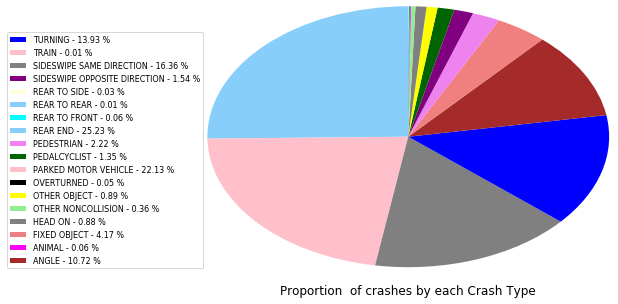

```python
colors = ['lightskyblue','pink','grey','blue','brown','lightcoral','violet','purple', 'darkgreen','yellow','grey','lightgreen','magenta','cyan','black','lightyellow']
explode = (0,0,0,0,0,0,0,0,0,0,0,0,0,0,0,0,0,0)
patches, texts = plt.pie(data_plot, startangle=90,explode = explode,colors=colors, radius=1.5)
labels = ['{0} - {1:1.2f} %'.format(i,j) for i,j in zip(data_plot.index,percent)]
sort_legend = True
if sort_legend:
    patches, labels, dummy =  zip(*sorted(zip(patches, labels, data_plot.index),
                                          key=lambda data_plot: data_plot[2],
                                          reverse=True));

plt.legend(patches, labels, loc='upper right', bbox_to_anchor=(-0.1, 1.),
           fontsize=8);
plt.title('Proportion  of crashes by each Crash Type', y = -0.25  );
plt.savefig('piechart.png', bbox_inches='tight');
```

### Counting Total Number of Crashes by Year

```python
Total_Crashes_Per_year = df.groupby('year')['CRASH_DATE'].count()
```

### Calculating the percentage of occurence of each crash type by Year

```python
d = df.groupby('year').FIRST_CRASH_TYPE.value_counts()*100/Total_Crashes_Per_year
df2 = pd.DataFrame({'Year':d.index, 'Proportion':d.values})
df2[['year', 'cause']] = pd.DataFrame(df2['Year'].tolist(), index=df2.index)
del df2['Year']
```

### Function to plot the Crash Type Percentages per Year as a Pie Chart

```python
def pie_chart(value):
    patches, texts = plt.pie(df2[df2.year ==value].Proportion, startangle=90,radius=1 );
    labels = ['{0} - {1:1.2f} %'.format(i,j) for i,j in zip(df2[df2.year ==value].cause,df2[df2.year ==value].Proportion)]
    sort_legend = True
    if sort_legend:
        patches, labels, dummy =  zip(*sorted(zip(patches, labels, data_plot.index),
                                          key=lambda data_plot: data_plot[2],
                                          reverse=True));
    plt.legend(patches, labels, loc='upper right', bbox_to_anchor=(-0.1, 1.),
           fontsize=8);
```

### Plotting Crash Type Percentages per Year as a Pie Chart

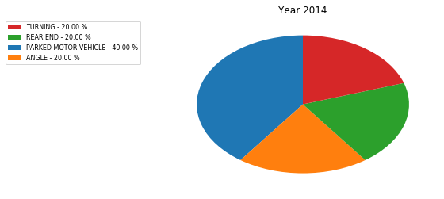

```python
pie_chart(2014);
plt.title("Year 2014");
```

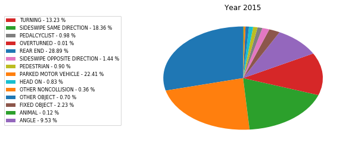

```python
pie_chart(2015);
plt.title("Year 2015");
```

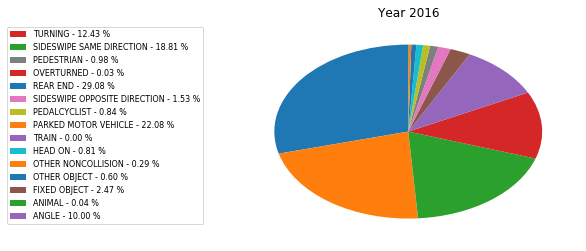

```python
pie_chart(2016);
plt.title("Year 2016");
```

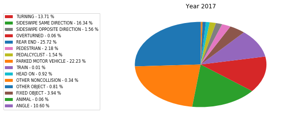

```python
pie_chart(2017);
plt.title("Year 2017");
```

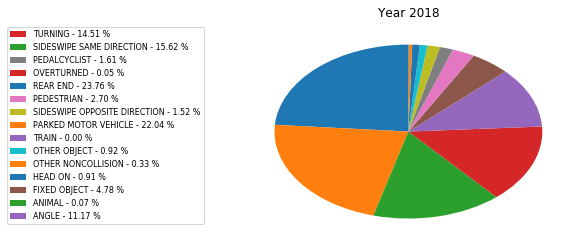

```python
pie_chart(2018);
plt.title("Year 2018");
```

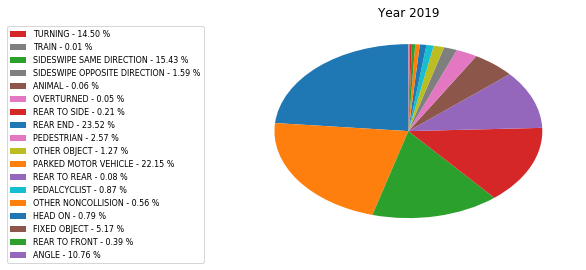

```python
pie_chart(2019);
plt.title("Year 2019");
```

### Inference

From the analysis performed above, we can infer that the maximum number of crashes occur due to "rear end" which constitutes to 25.23% of the total number of crashes followed by "parked motor vehicle" and "sideswipe same direction". On looking at charts for each year, we see that crashes due to "parked motor vehicles" is the highest in 2014. That may be due to limited data available for the beginning years. But as we go forward and the number of crashes increases, we observe that crashes due to "rear end" take a lead and fluctuates between 23%-29% over the next couple of years.

## Insight 2

**Analyze Hit and Run Cases in the following ways:** Identify proportion of hit and run cases to number of crashes that occur by each day of week Identify proportion of hit and run cases to number of crashes that occur by hour of day.

### Label for X- axis of chart

```python
weekday_order = ["Sun", "Mon", "Tue", "Wed", "Thu", "Fri", "Sat"]
```

### Plotting Hit and Run Cases by each day of the week

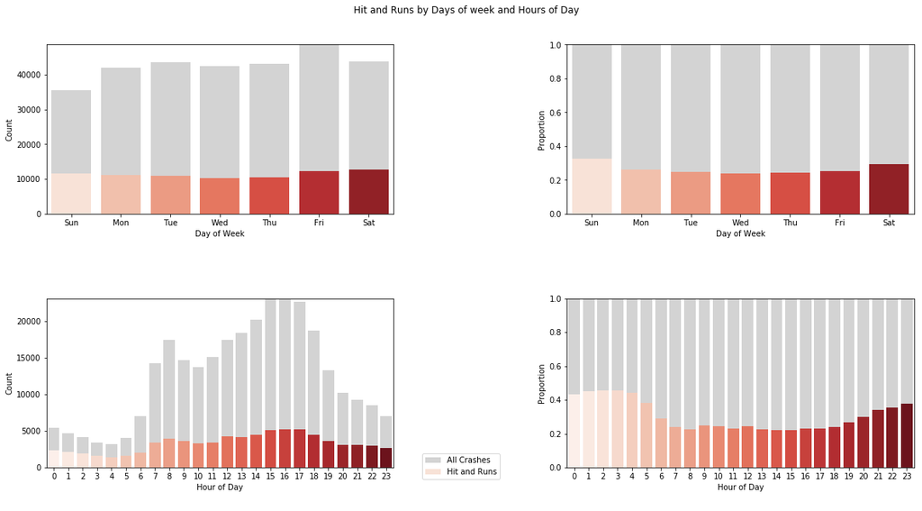

```python
# Subplots to show two plots side by side
fig, ax = plt.subplots(2, 2);

# Find sum of hit and run for each  day of the week
group_dow_sum = df.groupby('CRASH_DAY_OF_WEEK')['HIT_AND_RUN'].sum();

#Plot total crashes each day
plot_1 = sns.barplot(
    x=group_dow_sum.index, y=df.groupby("CRASH_DAY_OF_WEEK")["CRASH_DATE"].count().values,
    color="lightgray", ax=ax[0][0], label="All Crashes"
);
#Plot hit and run crashes each day
plot_1_Overlap = sns.barplot(
    x=group_dow_sum.index, y=group_dow_sum.values,
    palette="Reds", ax=ax[0][0], label="Hit and Runs"
);

# Set x and y  axis for first chart
ax[0][0].set_xticklabels(weekday_order);
ax[0][0].set_xlabel("Day of Week");
ax[0][0].set_ylabel("Count");
ax[0][0].set_ylim((0, df.groupby("CRASH_DAY_OF_WEEK")["CRASH_DATE"].count().max()));

# Set chart properties

fig.suptitle("Hit and Runs by Days of week and Hours of Day", y=0.95);
fig.subplots_adjust(wspace=0.5 , hspace = 0.5);
fig.set_size_inches((20, 10));
fig.legend(bbox_to_anchor=(0.45, 0.11));

# Find mean of hit and run for each  day of the week
group_dow_mean = df.groupby("CRASH_DAY_OF_WEEK")["HIT_AND_RUN"].mean();

#Plot total crashes each day
plot_2 = sns.barplot(
    x=group_dow_mean.index, y=np.ones(len(group_dow_mean.index)),
    color="lightgray", ax=ax[0][1]
);
#Plot proportion of hit and run each day
plot_2_Overlap = sns.barplot(
    x=group_dow_mean.index, y=group_dow_mean.values,
    palette="Reds", ax=ax[0][1]
);

# Set X and Y axis for second chart
ax[0][1].set_xticklabels(weekday_order);
ax[0][1].set_xlabel("Day of Week");
ax[0][1].set_ylabel("Proportion");
ax[0][1].set_ylim((0, 1));



group_hour_sum = df.groupby('CRASH_HOUR')['HIT_AND_RUN'].sum();
sns.barplot(
    x=group_hour_sum.index, y=df.groupby('CRASH_HOUR')['CRASH_DATE'].count().values,
    color="lightgray", ax=ax[1][0], label="All Crashes"
);
sns.barplot(
    x=group_hour_sum.index, y=group_hour_sum.values,
    palette="Reds", ax=ax[1][0], label="Hit and Runs"
);
ax[1][0].set_xlabel("Hour of Day");
ax[1][0].set_ylabel("Count");
ax[1][0].set_ylim((0, df.groupby('CRASH_HOUR')['CRASH_DATE'].count().max()));
group_hour_mean = df.groupby('CRASH_HOUR')['HIT_AND_RUN'].mean();
sns.barplot(
    x=group_hour_mean.index, y=np.ones(len(group_hour_mean.index)),
    color="lightgray", ax=ax[1][1]
);
sns.barplot(
    x=group_hour_mean.index, y=group_hour_mean.values,
    palette="Reds", ax=ax[1][1]
);
ax[1][1].set_xlabel("Hour of Day");
ax[1][1].set_ylabel("Proportion");
ax[1][1].set_ylim((0, 1));

plt.show();
```

### Inference

We can say that from above charts, the proportion of Hit and run cases is higher on Saturday and Sunday. The analysis by hours of day reveals that Hit and run cases are higher in late hours of day (10pm to 4am). This could be due to following reasons: -Lack of lighting -Lack of traffic monitoring at night -Increased activity on holidays To mitigate this, Chicago Police Department could arrange for improved supervision during night hours and holidays.

## Insight 3

We are trying to classify the traffic crashes based on the following parameters

- Lighting Condition
- Weather Condition
- Crash Hour
- Most Severe Injury

```python
df_ml = df.copy()
```

```python
df_ml['MOST_SEVERE_INJURY'] = df_ml['MOST_SEVERE_INJURY'].apply(lambda x: 0 if x == 'NO INDICATION OF INJURY' else 1)
```

```python
df_ml['WEATHER_CONDITION'] = df_ml['WEATHER_CONDITION'].apply(lambda x: 0 if x == 'CLEAR' else 1)
```

```python
df_ml.LIGHTING_CONDITION = df_ml.LIGHTING_CONDITION.replace('DAYLIGHT',1)
df_ml.LIGHTING_CONDITION = df_ml.LIGHTING_CONDITION.replace('DARKNESS, LIGHTED ROAD',0)
df_ml.LIGHTING_CONDITION = df_ml.LIGHTING_CONDITION.replace('DARKNESS',0)
df_ml.LIGHTING_CONDITION = df_ml.LIGHTING_CONDITION.replace('DUSK',0.5)
df_ml.LIGHTING_CONDITION = df_ml.LIGHTING_CONDITION.replace('DAWN',0.5)
```

```python
df_ml = df_ml[df_ml.LIGHTING_CONDITION != 'UNKNOWN'][['MOST_SEVERE_INJURY','CRASH_HOUR','WEATHER_CONDITION','LIGHTING_CONDITION']].copy()
```

```python
X = df_ml.drop('LIGHTING_CONDITION',axis=1)
Y = df_ml.LIGHTING_CONDITION
Y = Y.astype('int')
```

### Building the Classification Tree

```python
dt = tree.DecisionTreeClassifier(max_depth=5)
dt.fit(X,Y)
```

```
DecisionTreeClassifier(class_weight=None, criterion='gini', max_depth=5,
            max_features=None, max_leaf_nodes=None,
            min_impurity_decrease=0.0, min_impurity_split=None,
            min_samples_leaf=1, min_samples_split=2,
            min_weight_fraction_leaf=0.0, presort=False, random_state=None,
            splitter='best')
```

### This code will visualize a decision tree dt, trained with the attributes in X and the class labels in Y

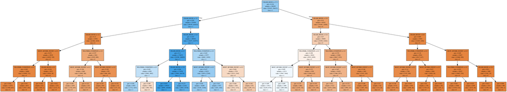

```python
dt_feature_names = list(X.columns)
dt_target_names = [str(s) for s in Y.unique()]
tree.export_graphviz(dt, out_file='tree.dot',
    feature_names=dt_feature_names, class_names=dt_target_names,
    filled=True)
graph = pydotplus.graph_from_dot_file('tree.dot')
Image(graph.create_png())
```

## Validating the inference

- During day light between 6.5 to 15.5 hours, the number of crashes are the most

#### Spliting crash hour into three different sets

- Less than 6.5
- Between 6.5 and 15.5
- Greater than 15.5

```python
df['BetweenHours'] = df['CRASH_HOUR'].apply(lambda x: 'Between  6.5 and 15.5' if ((x > 6.5) & (x <= 15.5)) else 'Less than 6.5'
                                              if(x <= 6.5) else 'Greater than 15.5')
```

#### Finding Total number of crashes by different time frames obtained before

```python
df_ml_plot = df.groupby('BetweenHours' ,as_index = False)['CRASH_DATE'].agg(['count']).rename(columns = {'count' : 'Total_Crashes'})
```

```python
df_ml_plot
```

| BetweenHours | Total_Crashes |
| --- | --- |
| Between 6.5 and 15.5 | 154319 |
| Greater than 15.5 | 112789 |
| Less than 6.5 | 31987 |

#### Plotting the inference

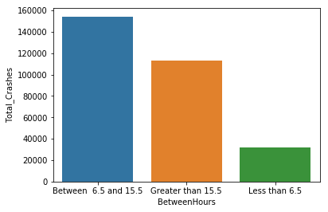

```python
sns.barplot(x= df_ml_plot.index ,y='Total_Crashes', data=df_ml_plot);
```

## References

- https://data.cityofchicago.org/Transportation/Traffic-Crashes-Crashes/85ca-t3if/data
- https://stackoverflow.com
- https://seaborn.pydata.org
- https://pandas.pydata.org/pandas-docs/stable/
- https://www.slidescarnival.com
- https://freshspectrum.com/how-pictures-help-discover-the-unexpected/
- http://www.animatedimages.org/cat-cleaning-1095.htm